# Risk Factor Analysis

## Outcome Variable

**Outcome Variable:** ever_stunted

## Predictor Variables

**Intervention Variable:** nhh

**Adjustment Set:**

unadjusted

## Stratifying Variables

The analysis was stratified on these variable(s):

- agecat
- studyid
- country

## Data Summary

| agecat | studyid | country | nhh | ever_stunted | n_cell | n | outcome_variable |
| --- | --- | --- | --- | --- | --- | --- | --- |
| 0-24 months | ki1000108-IRC | INDIA | 3 or less | 0 | 25 | 410 | ever_stunted |
| 0-24 months | ki1000108-IRC | INDIA | 3 or less | 1 | 33 | 410 | ever_stunted |
| 0-24 months | ki1000108-IRC | INDIA | 4-5 | 0 | 52 | 410 | ever_stunted |
| 0-24 months | ki1000108-IRC | INDIA | 4-5 | 1 | 106 | 410 | ever_stunted |
| 0-24 months | ki1000108-IRC | INDIA | 6-7 | 0 | 41 | 410 | ever_stunted |
| 0-24 months | ki1000108-IRC | INDIA | 6-7 | 1 | 66 | 410 | ever_stunted |
| 0-24 months | ki1000108-IRC | INDIA | 8+ | 0 | 29 | 410 | ever_stunted |
| 0-24 months | ki1000108-IRC | INDIA | 8+ | 1 | 58 | 410 | ever_stunted |
| 0-24 months | ki1000304b-SAS-FoodSuppl | INDIA | 3 or less | 0 | 9 | 418 | ever_stunted |
| 0-24 months | ki1000304b-SAS-FoodSuppl | INDIA | 3 or less | 1 | 29 | 418 | ever_stunted |
| 0-24 months | ki1000304b-SAS-FoodSuppl | INDIA | 4-5 | 0 | 35 | 418 | ever_stunted |
| 0-24 months | ki1000304b-SAS-FoodSuppl | INDIA | 4-5 | 1 | 148 | 418 | ever_stunted |
| 0-24 months | ki1000304b-SAS-FoodSuppl | INDIA | 6-7 | 0 | 16 | 418 | ever_stunted |
| 0-24 months | ki1000304b-SAS-FoodSuppl | INDIA | 6-7 | 1 | 111 | 418 | ever_stunted |
| 0-24 months | ki1000304b-SAS-FoodSuppl | INDIA | 8+ | 0 | 12 | 418 | ever_stunted |
| 0-24 months | ki1000304b-SAS-FoodSuppl | INDIA | 8+ | 1 | 58 | 418 | ever_stunted |
| 0-24 months | ki1017093-NIH-Birth | BANGLADESH | 3 or less | 0 | 47 | 629 | ever_stunted |
| 0-24 months | ki1017093-NIH-Birth | BANGLADESH | 3 or less | 1 | 70 | 629 | ever_stunted |
| 0-24 months | ki1017093-NIH-Birth | BANGLADESH | 4-5 | 0 | 77 | 629 | ever_stunted |
| 0-24 months | ki1017093-NIH-Birth | BANGLADESH | 4-5 | 1 | 187 | 629 | ever_stunted |
| 0-24 months | ki1017093-NIH-Birth | BANGLADESH | 6-7 | 0 | 42 | 629 | ever_stunted |
| 0-24 months | ki1017093-NIH-Birth | BANGLADESH | 6-7 | 1 | 100 | 629 | ever_stunted |
| 0-24 months | ki1017093-NIH-Birth | BANGLADESH | 8+ | 0 | 45 | 629 | ever_stunted |
| 0-24 months | ki1017093-NIH-Birth | BANGLADESH | 8+ | 1 | 61 | 629 | ever_stunted |
| 0-24 months | ki1017093b-PROVIDE | BANGLADESH | 3 or less | 0 | 82 | 700 | ever_stunted |
| 0-24 months | ki1017093b-PROVIDE | BANGLADESH | 3 or less | 1 | 58 | 700 | ever_stunted |
| 0-24 months | ki1017093b-PROVIDE | BANGLADESH | 4-5 | 0 | 179 | 700 | ever_stunted |
| 0-24 months | ki1017093b-PROVIDE | BANGLADESH | 4-5 | 1 | 143 | 700 | ever_stunted |
| 0-24 months | ki1017093b-PROVIDE | BANGLADESH | 6-7 | 0 | 84 | 700 | ever_stunted |
| 0-24 months | ki1017093b-PROVIDE | BANGLADESH | 6-7 | 1 | 67 | 700 | ever_stunted |

[output cut: 114 more lines]

The following strata were considered:

- agecat: 0-24 months, studyid: ki1000108-IRC, country: INDIA
- agecat: 0-24 months, studyid: ki1000304b-SAS-FoodSuppl, country: INDIA
- agecat: 0-24 months, studyid: ki1017093-NIH-Birth, country: BANGLADESH
- agecat: 0-24 months, studyid: ki1017093b-PROVIDE, country: BANGLADESH
- agecat: 0-24 months, studyid: ki1017093c-NIH-Crypto, country: BANGLADESH
- agecat: 0-24 months, studyid: ki1148112-LCNI-5, country: MALAWI
- agecat: 0-6 months, studyid: ki1000108-IRC, country: INDIA
- agecat: 0-6 months, studyid: ki1000304b-SAS-FoodSuppl, country: INDIA
- agecat: 0-6 months, studyid: ki1017093-NIH-Birth, country: BANGLADESH
- agecat: 0-6 months, studyid: ki1017093b-PROVIDE, country: BANGLADESH
- agecat: 0-6 months, studyid: ki1017093c-NIH-Crypto, country: BANGLADESH
- agecat: 0-6 months, studyid: ki1148112-LCNI-5, country: MALAWI
- agecat: 6-24 months, studyid: ki1000108-IRC, country: INDIA
- agecat: 6-24 months, studyid: ki1000304b-SAS-FoodSuppl, country: INDIA
- agecat: 6-24 months, studyid: ki1017093-NIH-Birth, country: BANGLADESH
- agecat: 6-24 months, studyid: ki1017093b-PROVIDE, country: BANGLADESH
- agecat: 6-24 months, studyid: ki1017093c-NIH-Crypto, country: BANGLADESH
- agecat: 6-24 months, studyid: ki1148112-LCNI-5, country: MALAWI

### Dropped Strata

Some strata were dropped due to rare outcomes:

- agecat: 0-6 months, studyid: ki1148112-LCNI-5, country: MALAWI

## Methods Detail

We’re interested in the causal parameters $E[Y_a]$ for all values of $a \in \mathcal{A}$. These parameters represent the mean outcome if, possibly contrary to fact, we intervened to set all units to have $A=a$. Under the randomization and positivity assumptions, these are identified by the statistical parameters $\psi_a=E_W[E_{Y|A,W}(Y|A=a,W)]$. In addition, we’re interested in the mean of $Y$, $E[Y]$ under no intervention (the observed mean). We will estimate these parameters by using SuperLearner to fit the relevant likelihood factors – $E_{Y|A,W}(Y|A=a,W)$ and $p(A=a|W)$, and then updating our likelihood fit using a joint TMLE.

For unadjusted analyses ($W=\{\}$), initial likelihoods were estimated using Lrnr_glm to estimate the simple $E(Y|A)$ and Lrnr_mean to estimate $p(A)$. For adjusted analyses, a small library containing Lrnr_glmnet, Lrnr_xgboost, and Lrnr_mean was used.

Having estimated these parameters, we will then use the delta method to estimate relative risks and attributable risks relative to a prespecified baseline level of $A$.

# Results Detail

## Results Plots

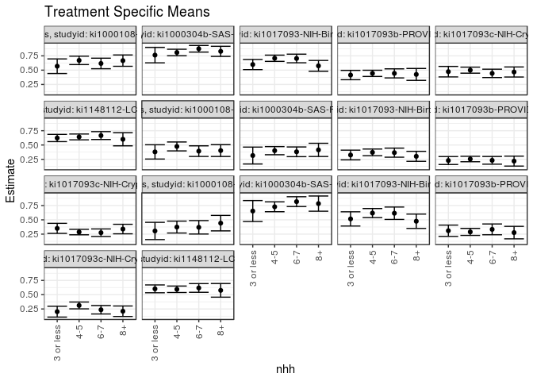

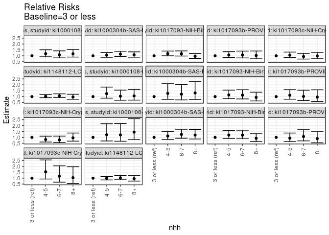

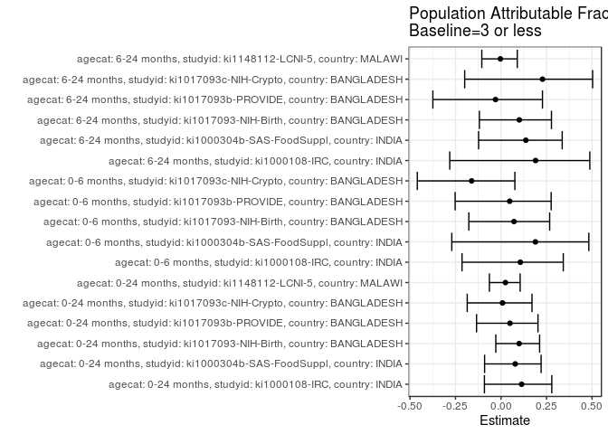

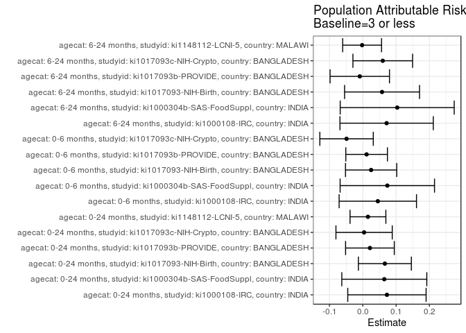

## Results Table

### Parameter: TSM

| agecat | studyid | country | intervention_level | baseline_level | estimate | ci_lower | ci_upper |
| --- | --- | --- | --- | --- | --- | --- | --- |
| 0-24 months | ki1000108-IRC | INDIA | 3 or less | NA | 0.5689655 | 0.4413618 | 0.6965692 |
| 0-24 months | ki1000108-IRC | INDIA | 4-5 | NA | 0.6708861 | 0.5975281 | 0.7442441 |
| 0-24 months | ki1000108-IRC | INDIA | 6-7 | NA | 0.6168224 | 0.5245936 | 0.7090512 |
| 0-24 months | ki1000108-IRC | INDIA | 8+ | NA | 0.6666667 | 0.5674893 | 0.7658440 |
| 0-24 months | ki1000304b-SAS-FoodSuppl | INDIA | 3 or less | NA | 0.7631579 | 0.6278220 | 0.8984938 |
| 0-24 months | ki1000304b-SAS-FoodSuppl | INDIA | 4-5 | NA | 0.8087432 | 0.7516931 | 0.8657933 |
| 0-24 months | ki1000304b-SAS-FoodSuppl | INDIA | 6-7 | NA | 0.8740157 | 0.8162349 | 0.9317966 |
| 0-24 months | ki1000304b-SAS-FoodSuppl | INDIA | 8+ | NA | 0.8285714 | 0.7401768 | 0.9169660 |
| 0-24 months | ki1017093-NIH-Birth | BANGLADESH | 3 or less | NA | 0.5982906 | 0.5093883 | 0.6871928 |
| 0-24 months | ki1017093-NIH-Birth | BANGLADESH | 4-5 | NA | 0.7083333 | 0.6534609 | 0.7632057 |
| 0-24 months | ki1017093-NIH-Birth | BANGLADESH | 6-7 | NA | 0.7042254 | 0.6291001 | 0.7793506 |
| 0-24 months | ki1017093-NIH-Birth | BANGLADESH | 8+ | NA | 0.5754717 | 0.4813031 | 0.6696403 |
| 0-24 months | ki1017093b-PROVIDE | BANGLADESH | 3 or less | NA | 0.4142857 | 0.3326298 | 0.4959416 |
| 0-24 months | ki1017093b-PROVIDE | BANGLADESH | 4-5 | NA | 0.4440994 | 0.3897907 | 0.4984081 |
| 0-24 months | ki1017093b-PROVIDE | BANGLADESH | 6-7 | NA | 0.4437086 | 0.3644092 | 0.5230081 |
| 0-24 months | ki1017093b-PROVIDE | BANGLADESH | 8+ | NA | 0.4252874 | 0.3213275 | 0.5292472 |
| 0-24 months | ki1017093c-NIH-Crypto | BANGLADESH | 3 or less | NA | 0.4736842 | 0.3819672 | 0.5654012 |
| 0-24 months | ki1017093c-NIH-Crypto | BANGLADESH | 4-5 | NA | 0.5000000 | 0.4469737 | 0.5530263 |
| 0-24 months | ki1017093c-NIH-Crypto | BANGLADESH | 6-7 | NA | 0.4438202 | 0.3707844 | 0.5168560 |
| 0-24 months | ki1017093c-NIH-Crypto | BANGLADESH | 8+ | NA | 0.4677419 | 0.3798623 | 0.5556216 |
| 0-24 months | ki1148112-LCNI-5 | MALAWI | 3 or less | NA | 0.6222222 | 0.5588332 | 0.6856112 |
| 0-24 months | ki1148112-LCNI-5 | MALAWI | 4-5 | NA | 0.6411765 | 0.5901608 | 0.6921922 |
| 0-24 months | ki1148112-LCNI-5 | MALAWI | 6-7 | NA | 0.6648352 | 0.5962130 | 0.7334574 |
| 0-24 months | ki1148112-LCNI-5 | MALAWI | 8+ | NA | 0.6000000 | 0.4851660 | 0.7148340 |
| 0-6 months | ki1000108-IRC | INDIA | 3 or less | NA | 0.3793103 | 0.2542847 | 0.5043360 |
| 0-6 months | ki1000108-IRC | INDIA | 4-5 | NA | 0.4746835 | 0.3967252 | 0.5526419 |
| 0-6 months | ki1000108-IRC | INDIA | 6-7 | NA | 0.3925234 | 0.2998865 | 0.4851603 |
| 0-6 months | ki1000108-IRC | INDIA | 8+ | NA | 0.4022989 | 0.2991332 | 0.5054645 |
| 0-6 months | ki1000304b-SAS-FoodSuppl | INDIA | 3 or less | NA | 0.3157895 | 0.1678198 | 0.4637591 |
| 0-6 months | ki1000304b-SAS-FoodSuppl | INDIA | 4-5 | NA | 0.4010989 | 0.3298073 | 0.4723905 |
| 0-6 months | ki1000304b-SAS-FoodSuppl | INDIA | 6-7 | NA | 0.3809524 | 0.2960572 | 0.4658475 |
| 0-6 months | ki1000304b-SAS-FoodSuppl | INDIA | 8+ | NA | 0.4142857 | 0.2987504 | 0.5298210 |
| 0-6 months | ki1017093-NIH-Birth | BANGLADESH | 3 or less | NA | 0.3247863 | 0.2398643 | 0.4097083 |
| 0-6 months | ki1017093-NIH-Birth | BANGLADESH | 4-5 | NA | 0.3712121 | 0.3128871 | 0.4295371 |
| 0-6 months | ki1017093-NIH-Birth | BANGLADESH | 6-7 | NA | 0.3661972 | 0.2868952 | 0.4454992 |
| 0-6 months | ki1017093-NIH-Birth | BANGLADESH | 8+ | NA | 0.3018868 | 0.2144235 | 0.3893500 |
| 0-6 months | ki1017093b-PROVIDE | BANGLADESH | 3 or less | NA | 0.2285714 | 0.1589644 | 0.2981785 |
| 0-6 months | ki1017093b-PROVIDE | BANGLADESH | 4-5 | NA | 0.2546584 | 0.2070386 | 0.3022782 |
| 0-6 months | ki1017093b-PROVIDE | BANGLADESH | 6-7 | NA | 0.2317881 | 0.1644352 | 0.2991410 |
| 0-6 months | ki1017093b-PROVIDE | BANGLADESH | 8+ | NA | 0.2183908 | 0.1315126 | 0.3052690 |
| 0-6 months | ki1017093c-NIH-Crypto | BANGLADESH | 3 or less | NA | 0.3508772 | 0.2632128 | 0.4385416 |
| 0-6 months | ki1017093c-NIH-Crypto | BANGLADESH | 4-5 | NA | 0.2865497 | 0.2385981 | 0.3345014 |
| 0-6 months | ki1017093c-NIH-Crypto | BANGLADESH | 6-7 | NA | 0.2752809 | 0.2096214 | 0.3409404 |
| 0-6 months | ki1017093c-NIH-Crypto | BANGLADESH | 8+ | NA | 0.3387097 | 0.2553543 | 0.4220651 |
| 6-24 months | ki1000108-IRC | INDIA | 3 or less | NA | 0.3055556 | 0.1547620 | 0.4563491 |
| 6-24 months | ki1000108-IRC | INDIA | 4-5 | NA | 0.3734940 | 0.2692057 | 0.4777823 |
| 6-24 months | ki1000108-IRC | INDIA | 6-7 | NA | 0.3692308 | 0.2516605 | 0.4868011 |
| 6-24 months | ki1000108-IRC | INDIA | 8+ | NA | 0.4423077 | 0.3070294 | 0.5775860 |
| 6-24 months | ki1000304b-SAS-FoodSuppl | INDIA | 3 or less | NA | 0.6538462 | 0.4706024 | 0.8370899 |
| 6-24 months | ki1000304b-SAS-FoodSuppl | INDIA | 4-5 | NA | 0.7281553 | 0.6420565 | 0.8142542 |
| 6-24 months | ki1000304b-SAS-FoodSuppl | INDIA | 6-7 | NA | 0.8181818 | 0.7318558 | 0.9045078 |
| 6-24 months | ki1000304b-SAS-FoodSuppl | INDIA | 8+ | NA | 0.7837838 | 0.6508654 | 0.9167021 |
| 6-24 months | ki1017093-NIH-Birth | BANGLADESH | 3 or less | NA | 0.5161290 | 0.3915553 | 0.6407028 |
| 6-24 months | ki1017093-NIH-Birth | BANGLADESH | 4-5 | NA | 0.6180556 | 0.5385841 | 0.6975270 |
| 6-24 months | ki1017093-NIH-Birth | BANGLADESH | 6-7 | NA | 0.6153846 | 0.5072617 | 0.7235075 |
| 6-24 months | ki1017093-NIH-Birth | BANGLADESH | 8+ | NA | 0.4754098 | 0.3499058 | 0.6009139 |
| 6-24 months | ki1017093b-PROVIDE | BANGLADESH | 3 or less | NA | 0.3095238 | 0.2105531 | 0.4084945 |
| 6-24 months | ki1017093b-PROVIDE | BANGLADESH | 4-5 | NA | 0.2890995 | 0.2278628 | 0.3503362 |
| 6-24 months | ki1017093b-PROVIDE | BANGLADESH | 6-7 | NA | 0.3333333 | 0.2389310 | 0.4277357 |
| 6-24 months | ki1017093b-PROVIDE | BANGLADESH | 8+ | NA | 0.2769231 | 0.1680200 | 0.3858261 |
| 6-24 months | ki1017093c-NIH-Crypto | BANGLADESH | 3 or less | NA | 0.2028986 | 0.1079148 | 0.2978823 |
| 6-24 months | ki1017093c-NIH-Crypto | BANGLADESH | 4-5 | NA | 0.3119658 | 0.2525464 | 0.3713852 |
| 6-24 months | ki1017093c-NIH-Crypto | BANGLADESH | 6-7 | NA | 0.2362205 | 0.1622738 | 0.3101671 |
| 6-24 months | ki1017093c-NIH-Crypto | BANGLADESH | 8+ | NA | 0.2105263 | 0.1187791 | 0.3022735 |
| 6-24 months | ki1148112-LCNI-5 | MALAWI | 3 or less | NA | 0.6020408 | 0.5334670 | 0.6706146 |
| 6-24 months | ki1148112-LCNI-5 | MALAWI | 4-5 | NA | 0.5945017 | 0.5380498 | 0.6509536 |
| 6-24 months | ki1148112-LCNI-5 | MALAWI | 6-7 | NA | 0.6178344 | 0.5417727 | 0.6938961 |
| 6-24 months | ki1148112-LCNI-5 | MALAWI | 8+ | NA | 0.5757576 | 0.4564387 | 0.6950764 |

### Parameter: E(Y)

| agecat | studyid | country | intervention_level | baseline_level | estimate | ci_lower | ci_upper |
| --- | --- | --- | --- | --- | --- | --- | --- |
| 0-24 months | ki1000108-IRC | INDIA | NA | NA | 0.6414634 | 0.5949863 | 0.6879405 |
| 0-24 months | ki1000304b-SAS-FoodSuppl | INDIA | NA | NA | 0.8277512 | 0.7915095 | 0.8639929 |
| 0-24 months | ki1017093-NIH-Birth | BANGLADESH | NA | NA | 0.6645469 | 0.6276196 | 0.7014742 |
| 0-24 months | ki1017093b-PROVIDE | BANGLADESH | NA | NA | 0.4357143 | 0.3989556 | 0.4724730 |
| 0-24 months | ki1017093c-NIH-Crypto | BANGLADESH | NA | NA | 0.4775726 | 0.4419904 | 0.5131548 |
| 0-24 months | ki1148112-LCNI-5 | MALAWI | NA | NA | 0.6376989 | 0.6047193 | 0.6706785 |
| 0-6 months | ki1000108-IRC | INDIA | NA | NA | 0.4243902 | 0.3764905 | 0.4722900 |
| 0-6 months | ki1000304b-SAS-FoodSuppl | INDIA | NA | NA | 0.3894231 | 0.3425088 | 0.4363374 |
| 0-6 months | ki1017093-NIH-Birth | BANGLADESH | NA | NA | 0.3497615 | 0.3124631 | 0.3870600 |
| 0-6 months | ki1017093b-PROVIDE | BANGLADESH | NA | NA | 0.2400000 | 0.2083392 | 0.2716608 |
| 0-6 months | ki1017093c-NIH-Crypto | BANGLADESH | NA | NA | 0.3021108 | 0.2694011 | 0.3348205 |
| 6-24 months | ki1000108-IRC | INDIA | NA | NA | 0.3771186 | 0.3151523 | 0.4390850 |
| 6-24 months | ki1000304b-SAS-FoodSuppl | INDIA | NA | NA | 0.7572016 | 0.7031798 | 0.8112234 |
| 6-24 months | ki1017093-NIH-Birth | BANGLADESH | NA | NA | 0.5739130 | 0.5216565 | 0.6261696 |
| 6-24 months | ki1017093b-PROVIDE | BANGLADESH | NA | NA | 0.3004386 | 0.2583143 | 0.3425629 |
| 6-24 months | ki1017093c-NIH-Crypto | BANGLADESH | NA | NA | 0.2628458 | 0.2244546 | 0.3012371 |
| 6-24 months | ki1148112-LCNI-5 | MALAWI | NA | NA | 0.6000000 | 0.5639396 | 0.6360604 |

### Parameter: RR

| agecat | studyid | country | intervention_level | baseline_level | estimate | ci_lower | ci_upper |
| --- | --- | --- | --- | --- | --- | --- | --- |
| 0-24 months | ki1000108-IRC | INDIA | 3 or less | 3 or less | 1.0000000 | 1.0000000 | 1.000000 |
| 0-24 months | ki1000108-IRC | INDIA | 4-5 | 3 or less | 1.1791331 | 0.9187607 | 1.513294 |
| 0-24 months | ki1000108-IRC | INDIA | 6-7 | 3 or less | 1.0841121 | 0.8279642 | 1.419505 |
| 0-24 months | ki1000108-IRC | INDIA | 8+ | 3 or less | 1.1717172 | 0.8952453 | 1.533570 |
| 0-24 months | ki1000304b-SAS-FoodSuppl | INDIA | 3 or less | 3 or less | 1.0000000 | 1.0000000 | 1.000000 |
| 0-24 months | ki1000304b-SAS-FoodSuppl | INDIA | 4-5 | 3 or less | 1.0597324 | 0.8756092 | 1.282573 |
| 0-24 months | ki1000304b-SAS-FoodSuppl | INDIA | 6-7 | 3 or less | 1.1452620 | 0.9477874 | 1.383881 |
| 0-24 months | ki1000304b-SAS-FoodSuppl | INDIA | 8+ | 3 or less | 1.0857143 | 0.8827484 | 1.335347 |
| 0-24 months | ki1017093-NIH-Birth | BANGLADESH | 3 or less | 3 or less | 1.0000000 | 1.0000000 | 1.000000 |
| 0-24 months | ki1017093-NIH-Birth | BANGLADESH | 4-5 | 3 or less | 1.1839286 | 1.0012645 | 1.399917 |
| 0-24 months | ki1017093-NIH-Birth | BANGLADESH | 6-7 | 3 or less | 1.1770624 | 0.9802971 | 1.413322 |
| 0-24 months | ki1017093-NIH-Birth | BANGLADESH | 8+ | 3 or less | 0.9618598 | 0.7711108 | 1.199794 |
| 0-24 months | ki1017093b-PROVIDE | BANGLADESH | 3 or less | 3 or less | 1.0000000 | 1.0000000 | 1.000000 |
| 0-24 months | ki1017093b-PROVIDE | BANGLADESH | 4-5 | 3 or less | 1.0719640 | 0.8500477 | 1.351815 |
| 0-24 months | ki1017093b-PROVIDE | BANGLADESH | 6-7 | 3 or less | 1.0710208 | 0.8208209 | 1.397486 |
| 0-24 months | ki1017093b-PROVIDE | BANGLADESH | 8+ | 3 or less | 1.0265557 | 0.7499108 | 1.405256 |
| 0-24 months | ki1017093c-NIH-Crypto | BANGLADESH | 3 or less | 3 or less | 1.0000000 | 1.0000000 | 1.000000 |
| 0-24 months | ki1017093c-NIH-Crypto | BANGLADESH | 4-5 | 3 or less | 1.0555556 | 0.8464543 | 1.316312 |
| 0-24 months | ki1017093c-NIH-Crypto | BANGLADESH | 6-7 | 3 or less | 0.9369538 | 0.7267085 | 1.208025 |
| 0-24 months | ki1017093c-NIH-Crypto | BANGLADESH | 8+ | 3 or less | 0.9874552 | 0.7539571 | 1.293267 |
| 0-24 months | ki1148112-LCNI-5 | MALAWI | 3 or less | 3 or less | 1.0000000 | 1.0000000 | 1.000000 |
| 0-24 months | ki1148112-LCNI-5 | MALAWI | 4-5 | 3 or less | 1.0304622 | 0.9055101 | 1.172656 |
| 0-24 months | ki1148112-LCNI-5 | MALAWI | 6-7 | 3 or less | 1.0684851 | 0.9242403 | 1.235242 |
| 0-24 months | ki1148112-LCNI-5 | MALAWI | 8+ | 3 or less | 0.9642857 | 0.7763262 | 1.197753 |
| 0-6 months | ki1000108-IRC | INDIA | 3 or less | 3 or less | 1.0000000 | 1.0000000 | 1.000000 |
| 0-6 months | ki1000108-IRC | INDIA | 4-5 | 3 or less | 1.2514384 | 0.8659151 | 1.808605 |
| 0-6 months | ki1000108-IRC | INDIA | 6-7 | 3 or less | 1.0348343 | 0.6899402 | 1.552137 |
| 0-6 months | ki1000108-IRC | INDIA | 8+ | 3 or less | 1.0606061 | 0.6985284 | 1.610364 |
| 0-6 months | ki1000304b-SAS-FoodSuppl | INDIA | 3 or less | 3 or less | 1.0000000 | 1.0000000 | 1.000000 |
| 0-6 months | ki1000304b-SAS-FoodSuppl | INDIA | 4-5 | 3 or less | 1.2701465 | 0.7694983 | 2.096525 |
| 0-6 months | ki1000304b-SAS-FoodSuppl | INDIA | 6-7 | 3 or less | 1.2063492 | 0.7180143 | 2.026810 |
| 0-6 months | ki1000304b-SAS-FoodSuppl | INDIA | 8+ | 3 or less | 1.3119048 | 0.7604834 | 2.263158 |
| 0-6 months | ki1017093-NIH-Birth | BANGLADESH | 3 or less | 3 or less | 1.0000000 | 1.0000000 | 1.000000 |
| 0-6 months | ki1017093-NIH-Birth | BANGLADESH | 4-5 | 3 or less | 1.1429426 | 0.8424503 | 1.550617 |
| 0-6 months | ki1017093-NIH-Birth | BANGLADESH | 6-7 | 3 or less | 1.1275019 | 0.8029205 | 1.583295 |
| 0-6 months | ki1017093-NIH-Birth | BANGLADESH | 8+ | 3 or less | 0.9294935 | 0.6291542 | 1.373206 |
| 0-6 months | ki1017093b-PROVIDE | BANGLADESH | 3 or less | 3 or less | 1.0000000 | 1.0000000 | 1.000000 |
| 0-6 months | ki1017093b-PROVIDE | BANGLADESH | 4-5 | 3 or less | 1.1141304 | 0.7793573 | 1.592706 |
| 0-6 months | ki1017093b-PROVIDE | BANGLADESH | 6-7 | 3 or less | 1.0140728 | 0.6656791 | 1.544804 |
| 0-6 months | ki1017093b-PROVIDE | BANGLADESH | 8+ | 3 or less | 0.9554598 | 0.5789413 | 1.576850 |
| 0-6 months | ki1017093c-NIH-Crypto | BANGLADESH | 3 or less | 3 or less | 1.0000000 | 1.0000000 | 1.000000 |
| 0-6 months | ki1017093c-NIH-Crypto | BANGLADESH | 4-5 | 3 or less | 0.8166667 | 0.6045737 | 1.103165 |
| 0-6 months | ki1017093c-NIH-Crypto | BANGLADESH | 6-7 | 3 or less | 0.7845506 | 0.5554031 | 1.108239 |
| 0-6 months | ki1017093c-NIH-Crypto | BANGLADESH | 8+ | 3 or less | 0.9653226 | 0.6797801 | 1.370807 |
| 6-24 months | ki1000108-IRC | INDIA | 3 or less | 3 or less | 1.0000000 | 1.0000000 | 1.000000 |
| 6-24 months | ki1000108-IRC | INDIA | 4-5 | 3 or less | 1.2223439 | 0.6933282 | 2.155004 |
| 6-24 months | ki1000108-IRC | INDIA | 6-7 | 3 or less | 1.2083916 | 0.6716451 | 2.174080 |
| 6-24 months | ki1000108-IRC | INDIA | 8+ | 3 or less | 1.4475524 | 0.8100002 | 2.586923 |
| 6-24 months | ki1000304b-SAS-FoodSuppl | INDIA | 3 or less | 3 or less | 1.0000000 | 1.0000000 | 1.000000 |
| 6-24 months | ki1000304b-SAS-FoodSuppl | INDIA | 4-5 | 3 or less | 1.1136493 | 0.8215720 | 1.509563 |
| 6-24 months | ki1000304b-SAS-FoodSuppl | INDIA | 6-7 | 3 or less | 1.2513369 | 0.9275155 | 1.688213 |
| 6-24 months | ki1000304b-SAS-FoodSuppl | INDIA | 8+ | 3 or less | 1.1987281 | 0.8638907 | 1.663346 |
| 6-24 months | ki1017093-NIH-Birth | BANGLADESH | 3 or less | 3 or less | 1.0000000 | 1.0000000 | 1.000000 |
| 6-24 months | ki1017093-NIH-Birth | BANGLADESH | 4-5 | 3 or less | 1.1974826 | 0.9109619 | 1.574121 |
| 6-24 months | ki1017093-NIH-Birth | BANGLADESH | 6-7 | 3 or less | 1.1923077 | 0.8845742 | 1.607098 |
| 6-24 months | ki1017093-NIH-Birth | BANGLADESH | 8+ | 3 or less | 0.9211066 | 0.6441162 | 1.317211 |
| 6-24 months | ki1017093b-PROVIDE | BANGLADESH | 3 or less | 3 or less | 1.0000000 | 1.0000000 | 1.000000 |
| 6-24 months | ki1017093b-PROVIDE | BANGLADESH | 4-5 | 3 or less | 0.9340139 | 0.6364746 | 1.370647 |
| 6-24 months | ki1017093b-PROVIDE | BANGLADESH | 6-7 | 3 or less | 1.0769231 | 0.7025558 | 1.650778 |
| 6-24 months | ki1017093b-PROVIDE | BANGLADESH | 8+ | 3 or less | 0.8946746 | 0.5389441 | 1.485205 |
| 6-24 months | ki1017093c-NIH-Crypto | BANGLADESH | 3 or less | 3 or less | 1.0000000 | 1.0000000 | 1.000000 |
| 6-24 months | ki1017093c-NIH-Crypto | BANGLADESH | 4-5 | 3 or less | 1.5375458 | 0.9275478 | 2.548707 |
| 6-24 months | ki1017093c-NIH-Crypto | BANGLADESH | 6-7 | 3 or less | 1.1642295 | 0.6629232 | 2.044627 |
| 6-24 months | ki1017093c-NIH-Crypto | BANGLADESH | 8+ | 3 or less | 1.0375940 | 0.5473418 | 1.966963 |
| 6-24 months | ki1148112-LCNI-5 | MALAWI | 3 or less | 3 or less | 1.0000000 | 1.0000000 | 1.000000 |
| 6-24 months | ki1148112-LCNI-5 | MALAWI | 4-5 | 3 or less | 0.9874774 | 0.8513827 | 1.145327 |
| 6-24 months | ki1148112-LCNI-5 | MALAWI | 6-7 | 3 or less | 1.0262334 | 0.8677737 | 1.213629 |
| 6-24 months | ki1148112-LCNI-5 | MALAWI | 8+ | 3 or less | 0.9563431 | 0.7549412 | 1.211475 |

### Parameter: PAR

| agecat | studyid | country | intervention_level | baseline_level | estimate | ci_lower | ci_upper |
| --- | --- | --- | --- | --- | --- | --- | --- |
| 0-24 months | ki1000108-IRC | INDIA | 3 or less | NA | 0.0724979 | -0.0451287 | 0.1901245 |
| 0-24 months | ki1000304b-SAS-FoodSuppl | INDIA | 3 or less | NA | 0.0645933 | -0.0630747 | 0.1922613 |
| 0-24 months | ki1017093-NIH-Birth | BANGLADESH | 3 or less | NA | 0.0662563 | -0.0132858 | 0.1457984 |
| 0-24 months | ki1017093b-PROVIDE | BANGLADESH | 3 or less | NA | 0.0214286 | -0.0517275 | 0.0945846 |
| 0-24 months | ki1017093c-NIH-Crypto | BANGLADESH | 3 or less | NA | 0.0038883 | -0.0806566 | 0.0884333 |
| 0-24 months | ki1148112-LCNI-5 | MALAWI | 3 or less | NA | 0.0154767 | -0.0383065 | 0.0692599 |
| 0-6 months | ki1000108-IRC | INDIA | 3 or less | NA | 0.0450799 | -0.0711236 | 0.1612834 |
| 0-6 months | ki1000304b-SAS-FoodSuppl | INDIA | 3 or less | NA | 0.0736336 | -0.0681265 | 0.2153937 |
| 0-6 months | ki1017093-NIH-Birth | BANGLADESH | 3 or less | NA | 0.0249752 | -0.0519664 | 0.1019168 |
| 0-6 months | ki1017093b-PROVIDE | BANGLADESH | 3 or less | NA | 0.0114286 | -0.0510974 | 0.0739545 |
| 0-6 months | ki1017093c-NIH-Crypto | BANGLADESH | 3 or less | NA | -0.0487664 | -0.1290370 | 0.0315043 |
| 6-24 months | ki1000108-IRC | INDIA | 3 or less | NA | 0.0715631 | -0.0685843 | 0.2117105 |
| 6-24 months | ki1000304b-SAS-FoodSuppl | INDIA | 3 or less | NA | 0.1033555 | -0.0678495 | 0.2745605 |
| 6-24 months | ki1017093-NIH-Birth | BANGLADESH | 3 or less | NA | 0.0577840 | -0.0547845 | 0.1703525 |
| 6-24 months | ki1017093b-PROVIDE | BANGLADESH | 3 or less | NA | -0.0090852 | -0.0983091 | 0.0801387 |
| 6-24 months | ki1017093c-NIH-Crypto | BANGLADESH | 3 or less | NA | 0.0599473 | -0.0296924 | 0.1495870 |
| 6-24 months | ki1148112-LCNI-5 | MALAWI | 3 or less | NA | -0.0020408 | -0.0604059 | 0.0563243 |

### Parameter: PAF

| agecat | studyid | country | intervention_level | baseline_level | estimate | ci_lower | ci_upper |
| --- | --- | --- | --- | --- | --- | --- | --- |
| 0-24 months | ki1000108-IRC | INDIA | 3 or less | NA | 0.1130195 | -0.0911727 | 0.2790011 |
| 0-24 months | ki1000304b-SAS-FoodSuppl | INDIA | 3 or less | NA | 0.0780347 | -0.0902029 | 0.2203102 |
| 0-24 months | ki1017093-NIH-Birth | BANGLADESH | 3 or less | NA | 0.0997015 | -0.0286889 | 0.2120675 |
| 0-24 months | ki1017093b-PROVIDE | BANGLADESH | 3 or less | NA | 0.0491803 | -0.1344841 | 0.2031109 |
| 0-24 months | ki1017093c-NIH-Crypto | BANGLADESH | 3 or less | NA | 0.0081419 | -0.1856716 | 0.1702740 |
| 0-24 months | ki1148112-LCNI-5 | MALAWI | 3 or less | NA | 0.0242696 | -0.0638471 | 0.1050877 |
| 0-6 months | ki1000108-IRC | INDIA | 3 or less | NA | 0.1062228 | -0.2142775 | 0.3421291 |
| 0-6 months | ki1000304b-SAS-FoodSuppl | INDIA | 3 or less | NA | 0.1890838 | -0.2704186 | 0.4823871 |
| 0-6 months | ki1017093-NIH-Birth | BANGLADESH | 3 or less | NA | 0.0714064 | -0.1768189 | 0.2672737 |
| 0-6 months | ki1017093b-PROVIDE | BANGLADESH | 3 or less | NA | 0.0476190 | -0.2519835 | 0.2755260 |
| 0-6 months | ki1017093c-NIH-Crypto | BANGLADESH | 3 or less | NA | -0.1614188 | -0.4599708 | 0.0760817 |
| 6-24 months | ki1000108-IRC | INDIA | 3 or less | NA | 0.1897628 | -0.2817232 | 0.4878112 |
| 6-24 months | ki1000304b-SAS-FoodSuppl | INDIA | 3 or less | NA | 0.1364967 | -0.1231626 | 0.3361264 |
| 6-24 months | ki1017093-NIH-Birth | BANGLADESH | 3 or less | NA | 0.1006843 | -0.1188697 | 0.2771555 |
| 6-24 months | ki1017093b-PROVIDE | BANGLADESH | 3 or less | NA | -0.0302398 | -0.3744450 | 0.2277653 |
| 6-24 months | ki1017093c-NIH-Crypto | BANGLADESH | 3 or less | NA | 0.2280702 | -0.1995971 | 0.5032702 |
| 6-24 months | ki1148112-LCNI-5 | MALAWI | 3 or less | NA | -0.0034014 | -0.1055483 | 0.0893077 |